# Homework on Statistical Distributions and Visualization

# Palmer Penguins

#### 0. Read file penguins.csv

- *Don’t forget to use all necessary parameters which were used in previous work*
- Look at the data (summary? structure? something else you want)

The `penguins` dataset contains data collected on three penguin species (Adelie, Chinstrap, and Gentoo) from three islands (Torgersen, Biscoe, and Dream) in the Palmer Archipelago, Antarctica.

It includes measurements like:

- `bill_length_mm` and `bill_depth_mm` - dimensions of the penguin’s bill.
- `flipper_length_mm` - length of the penguin’s flippers.
- `body_mass_g` - weight of the penguins in grams.
- `island` - the island where the penguins were observed.
- `sex`: the gender of the penguin.

Some rows may contain missing values (e.g., in `sex` column).

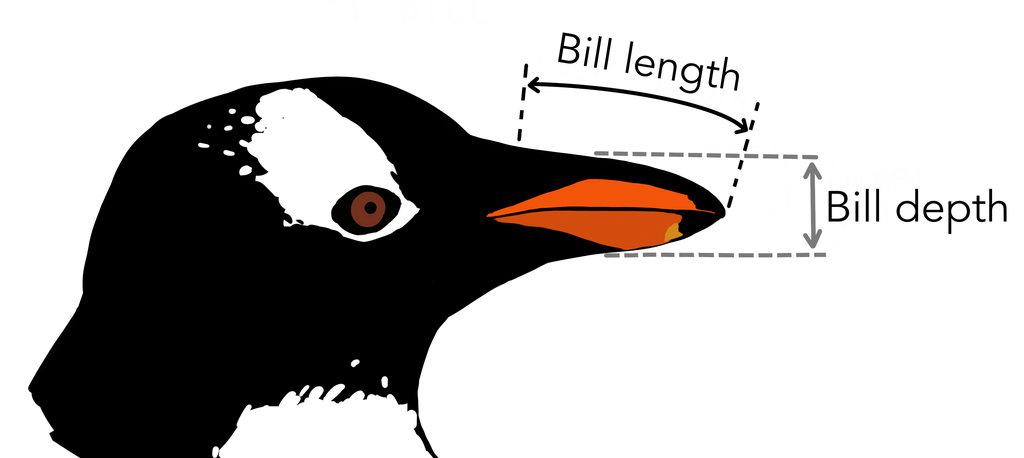

#### 1.* Delete rows containing NAs in all columns except `species, island, sex`.

```
##           species            island    bill_length_mm     bill_depth_mm
##                 0                 0                 2                 2
## flipper_length_mm       body_mass_g               sex
##                 2                 2                11
```

- remember `complete.cases()` and the ways we selected columns
- Ensure, that dataset was filtered!

#### 2. Create bar plot to show the number of observations (rows) for each `species` and delete legend (if `ggplot` used).

- Label the axes and legends
- Colors (`fill`) should also be different for each species
- `theme_classic()`, if `ggplot` used
- **This task can be solved using either basic R or `ggplot`**
- *Tip:* use `table()` (for basic R and `ggplot`) or `geom_bar()` (for `ggplot`)
- **Don’t forget to delete legend** *if ggplot used*

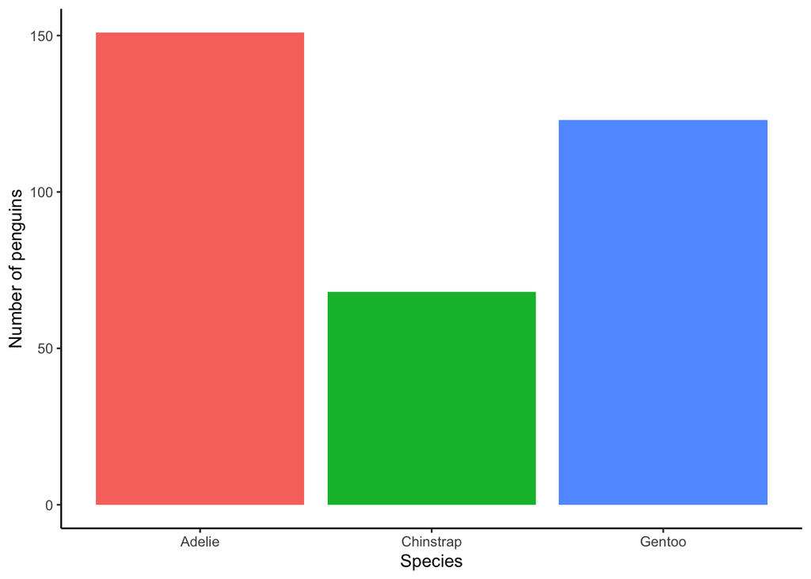

#### 3. Create stacked barplot scaled from 0 to 1 to show the proportion of `species` on each `island`.

- Label the axes and legends
- `theme_classic()`
- `fill` should represent `species`.
- Don’t forget change `position` parameter

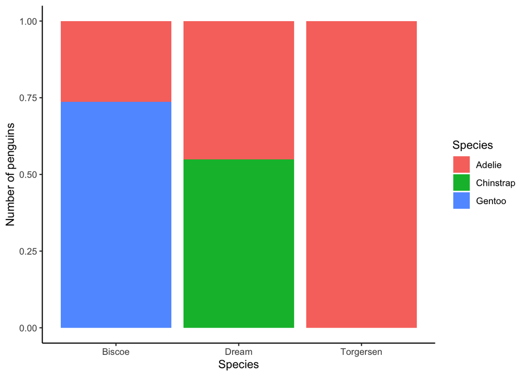

#### 4. Create a histogram for the `flipper_length_mm` and draw the vertical line to show mean value

- Label the axes
- Set the number of breaks to 10
- The histogram fill should be `"lightblue"` and border (color) should be `"black"`
- Vertical line color = `'red'`, `width = 1.2`
- `theme_bw()`, if `ggplot` used
- **This task can be solved using either basic R or `ggplot`**

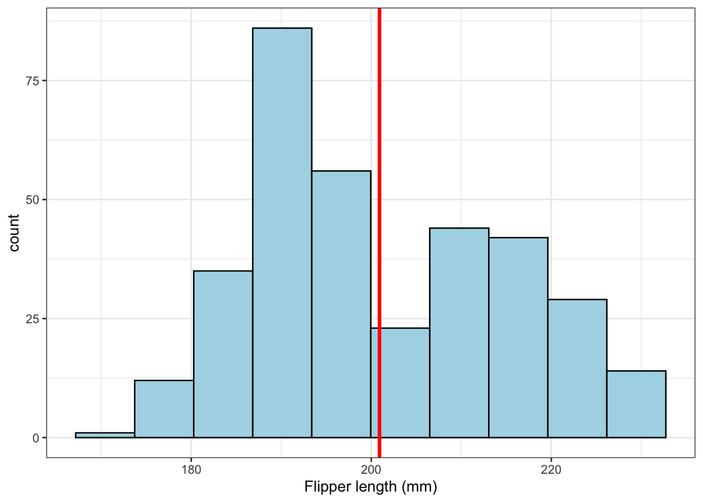

#### 5. Create a density plot for the `body_mass_g` variable. Fill the density regions based on `species`.

- Label the axes (y-axis is `Density`)
- `fill` should be different for each species
- Density plot should have `alpha=0.5`
- `theme_classic()`

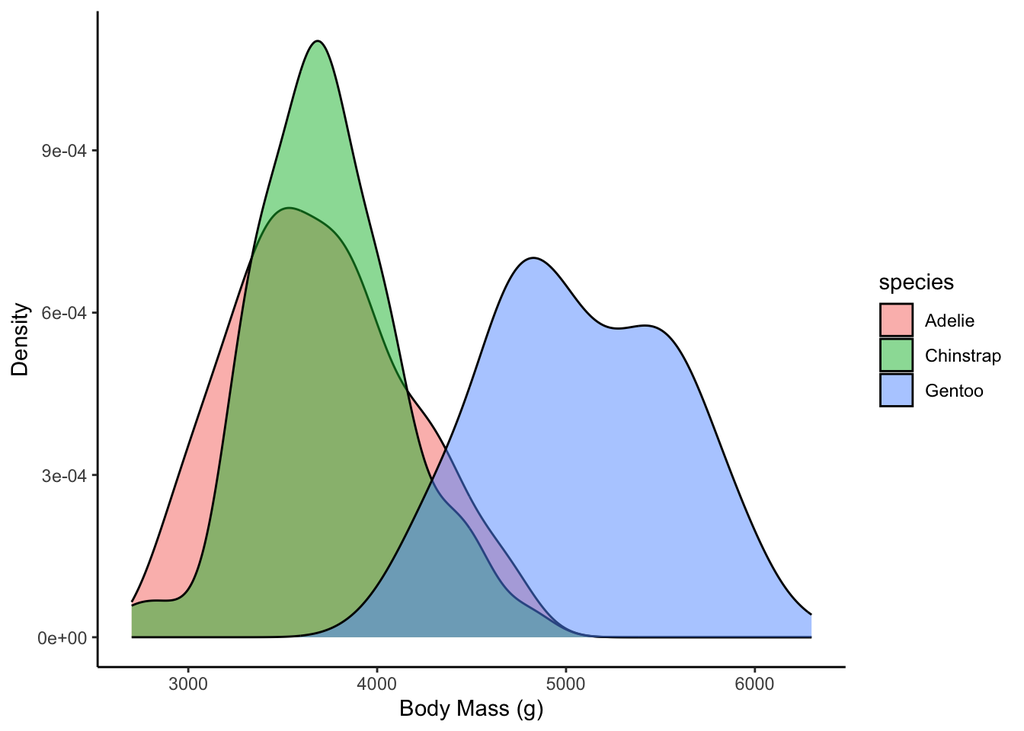

#### 6. Create a boxplots grouped by `sex` to compare `bill_length_mm` values. Save the plot in variable and show the plot.

- **Filter out observations without known `sex`** **(!)**
- Label the axes and legends
- Colors (`fill`) should also be different for each `sex`
- `theme_classic()`
- **When you save the plot in a variable, chart is not displayed. Don’t forget to show the plot by writing the variable name on a new line!**

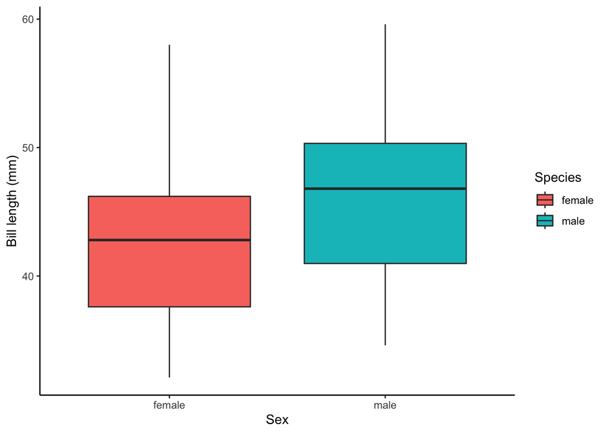

#### 7. Change the chart above: for each `sex` there must be 3 colored boxplots for each `species`. Each `species` should be *specifically* colored (`fill)`.

- *Tip:* just add (`+`) corresponding `aes(...)` to the variable

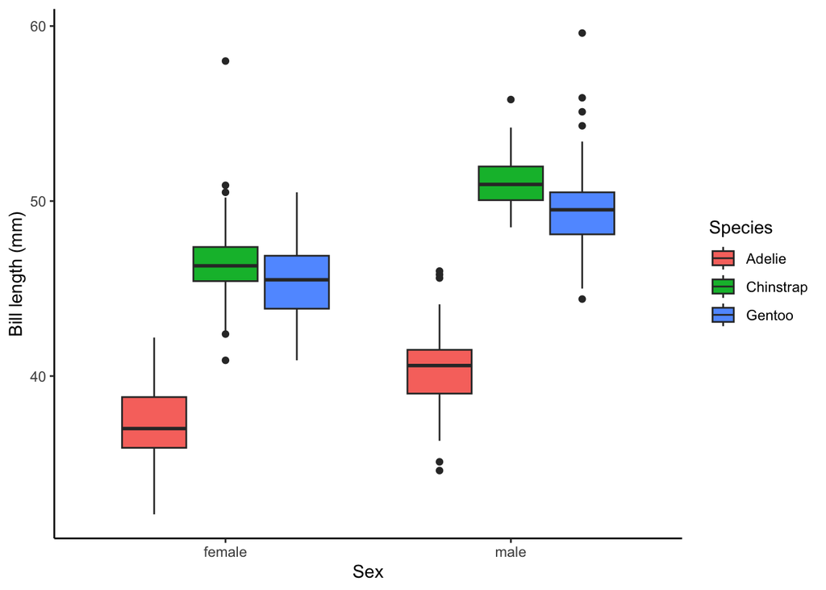

#### 8. Create a scatter plot to show the relationship between `bill_length_mm` and `bill_depth_mm`.

- Label the axes
- Make dots colored filled with `'blue'`
- Use `theme_classic`, if `ggplot` used
- **This task can be solved using either basic R or `ggplot`**

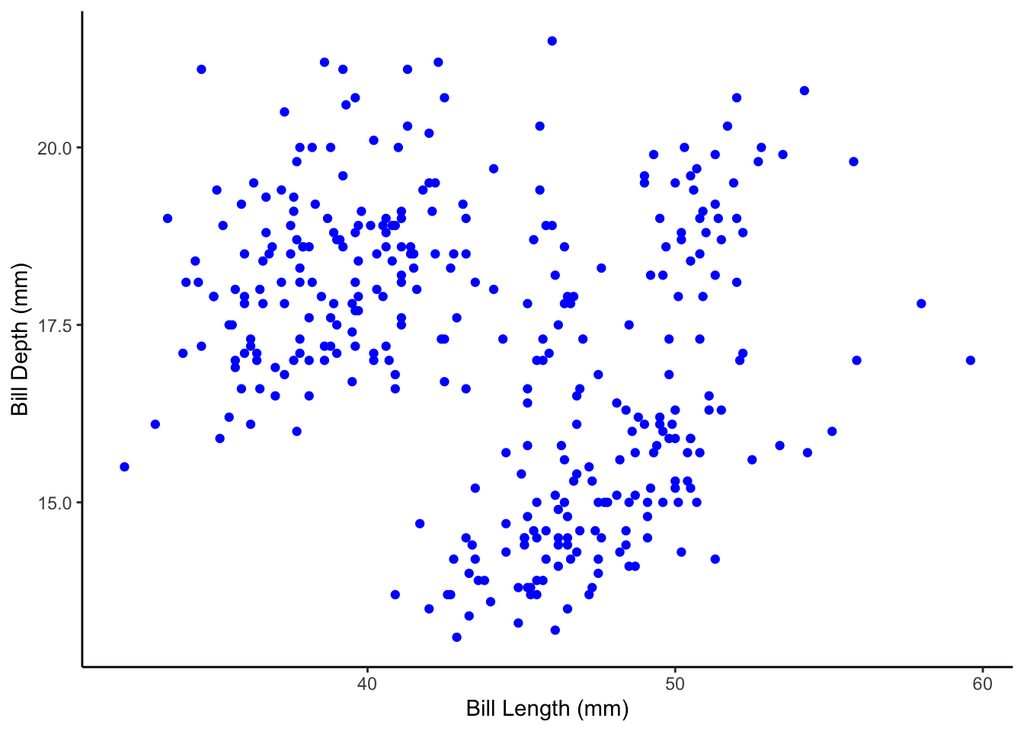

- Label the axes and legends
- Points should have `alpha=0.7`
- `theme_classic()`

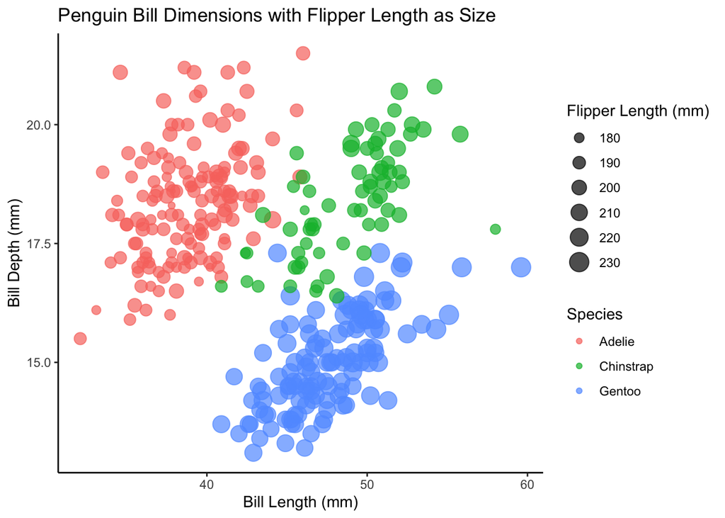

#### 10*. Add `geom_rug()` to the above plot to show distribution of points across the axes

- To do that you should save plot above in variable and add `geom_rug()`
- reduce *line width* to 0.5, *alpha* to 0.8 and set `show.legend = FALSE`

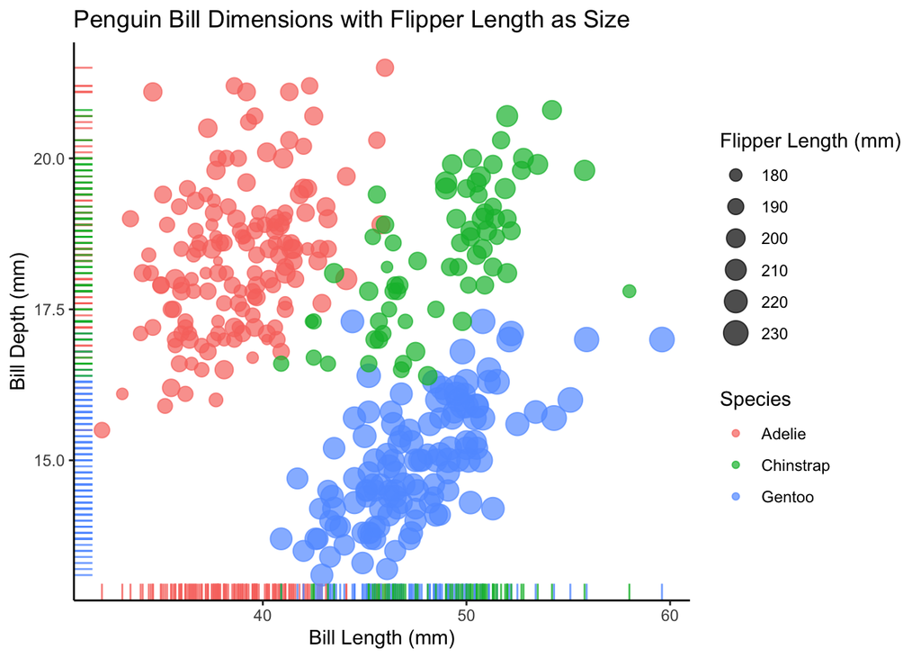